# 311 Service Calls of New York City

10/16/2016

## NYC 311 Service calls

311 is a public service phone number of many communities in North America, which provides access to many non-emergency municipal services[[1]](https://en.wikipedia.org/wiki/3-1-1). New York City now supports both phone call and online interfaces to 311 service, and provide open access to 311 service requests data from 2010 to present. There are several well-written articles online utilizing this dataset to come up with insights into data-driven urban management[[2]](https://www.wired.com/2010/11/ff_311_new_york/) or specific issues in NYC[[3]](http://www.newyorker.com/tech/elements/mapping-new-york-noise-complaints).

My questions:  
- What are the top complaints?  
- Are they the same across 5 boroughs?  
- Characterize some of the top complaints.

## The dataset

```r
fileurl <- "https://nycopendata.socrata.com/api/views/erm2-nwe9/rows.csv?accessType=DOWNLOAD"
file <- "data.csv"
download.file(fileurl, file, method = "curl" )
data <- data.table::fread(file, sep = ",", header = TRUE,
                          stringsAsFactors = FALSE,
                          na.strings = c("N/A", "", "NA", "Unspecified"))
nrow(data)           #dataset contains 13720953 observations
names(data)          #dataset contanins 53 variables
saveRDS(data, "all_data.RDS")
data <- readRDS("all_data.RDS")
```

## What are the top complaints?

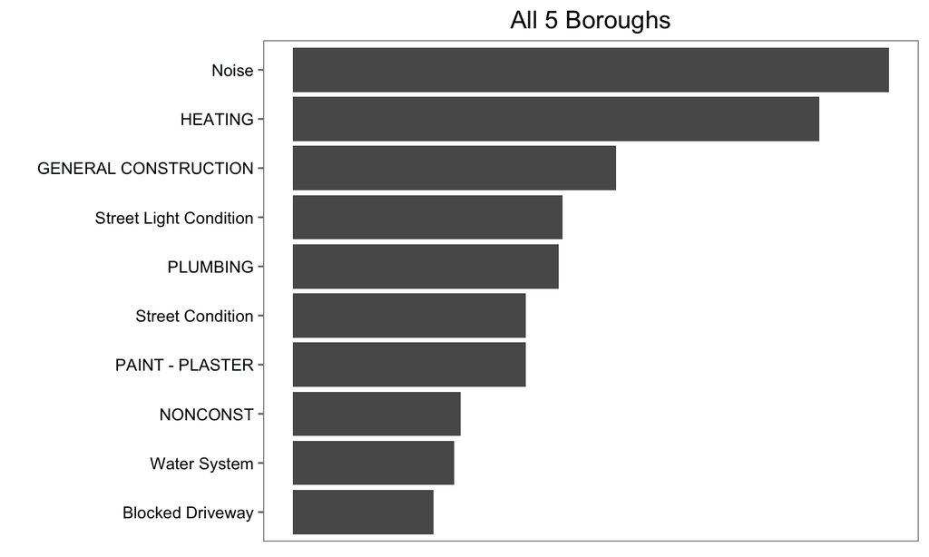

11.84% of 311 calls are noise complaints.

## Top 10 Complaints in Manhattan

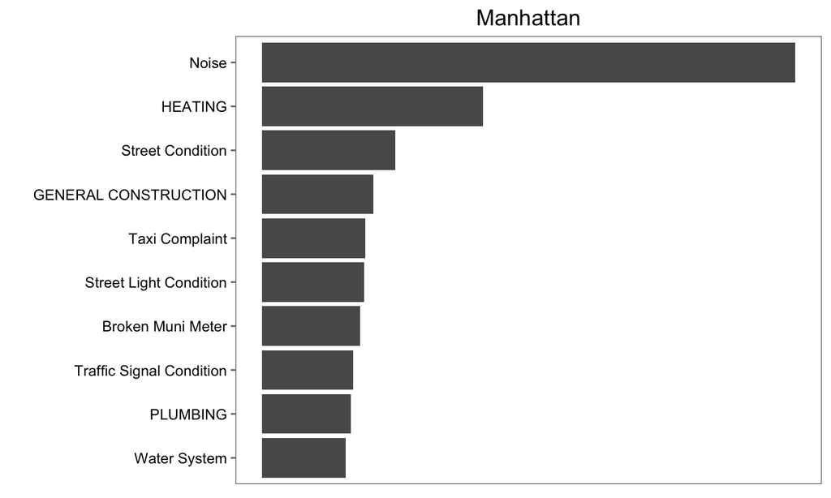

Queens, Bronx, Brooklyn are similar to Manhattan.

## Staten Island

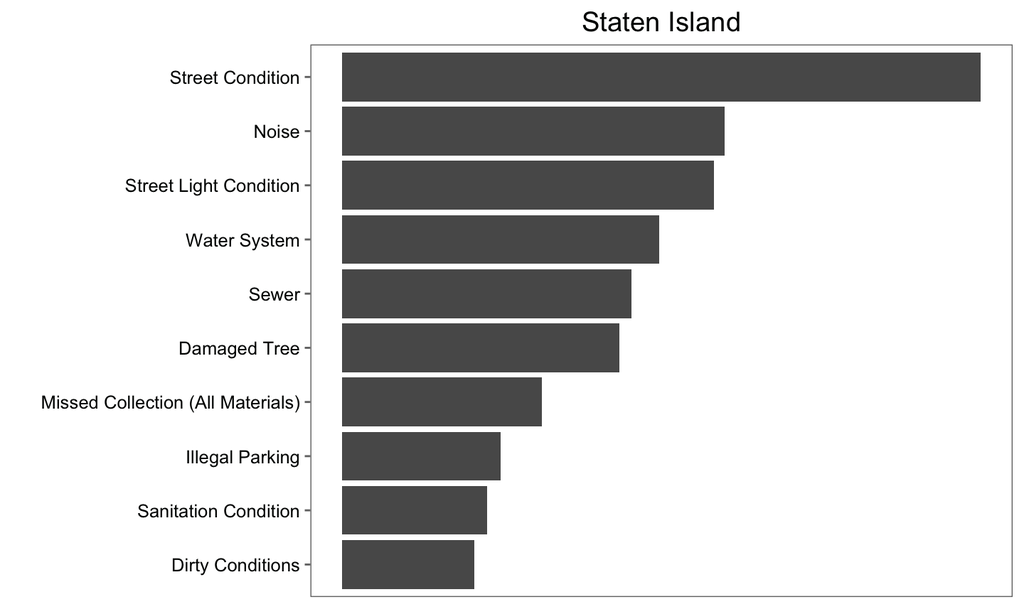

Staten Island residents' top complaint is street condition.

## Where are the noises?

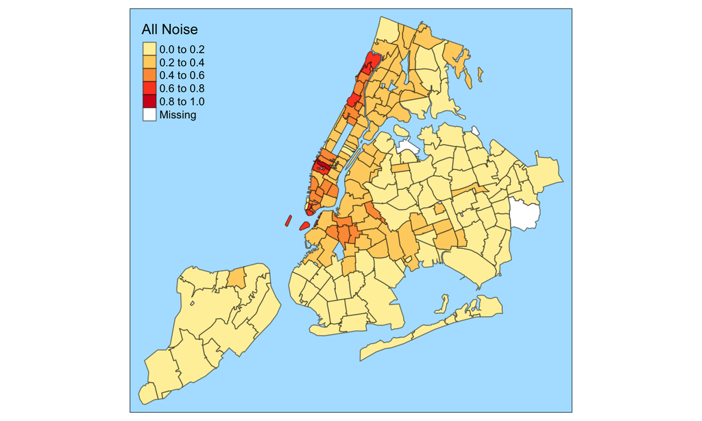

8 types of noises: *Construction*, *Dog and other animals*, *Vehicle*, *Music/TV/Talking*, *Alarm*, *Air Conditioner*, *Banging/Pounding* and *Other*.

## Loud Music and Banging

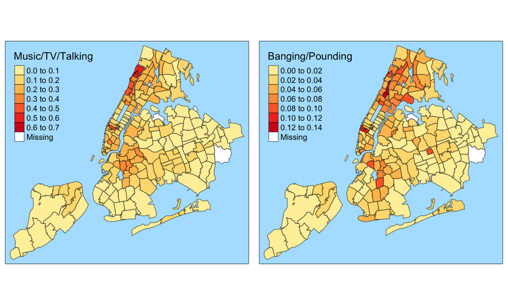

50% of noise are loud music/TV/talking.

## Construciton and Vehicle Noises

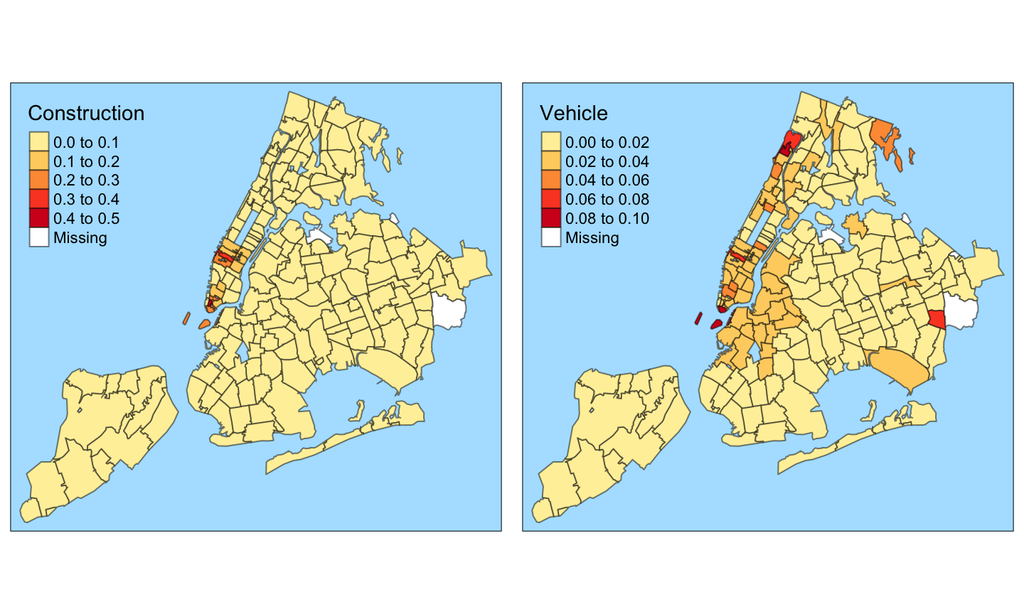

## Dogs/other animals and Alarm

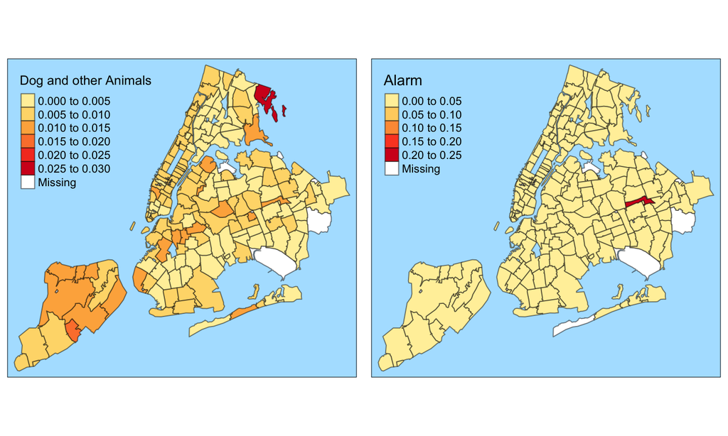

## Heating and Street Condition Complaints

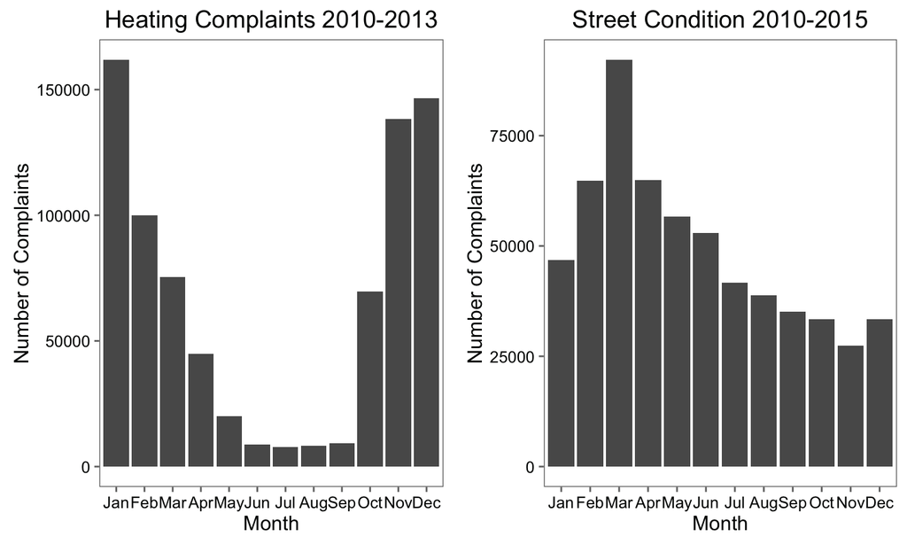